# Module 2: R4MS - Workshop 4

Author

Katie Dyck

Published

June 15, 2026

# 1 Housekeeping

Purge the global environment with the command `rm(list = ls())`.

# 2 Load packages

Packages loaded for this workshop include `tidyverse`, `cols4all`, `here`, `sf`, `terra`, `leaflet`, and `tmap`. `sf` is for working with spatial data, `terra` is for working with raster data, `leaflet` is for interactive maps, and `tmap` is for thematic maps.

# 3 About the data

The task is to wrangle a dataset to create a map of copepods in relation to temperature. We will be looking at data that contains measurements of copepod species richness from around Australia. Copepods are a type of zooplankton, perhaps the most abundant complex animals on the planet and an important part of ocean food-webs.

# 4 Download spatial data

The spreadsheet `copepods-raw.csv` has data on copepod measurements.

We have other datasets we will be using in our analysis, but nobody has explained what it is all for yet. We’ll have to figure that out.

Copepod species were counted using samples taken from a Continuous Plankton Recorder (CPR). The CPR was towed behind ‘ships of opportunity’ (including commercial and research vessels). ‘Silks’ run continuously through the CPR and the plankton are trapped onto the silks, kind of like a printer that runs all day and night to record plankton in the ocean.

| silk_id | segment_no | latitude | longitude | sample_time_utc | project | route | vessel | meanlong | region | richness_raw |
| --- | --- | --- | --- | --- | --- | --- | --- | --- | --- | --- |
| 1 | 1 | -28.34227 | 153.8139 | 26/06/2009 22:08 | AusCPR | BRSY | ANL Windarra | 153.2466 | East | 3 |
| 1 | 5 | -28.67602 | 153.8109 | 26/06/2009 23:12 | AusCPR | BRSY | ANL Windarra | 153.2466 | East | 21 |
| 1 | 9 | -29.00665 | 153.7558 | 27/06/2009 0:17 | AusCPR | BRSY | ANL Windarra | 153.2466 | East | 27 |
| 1 | 13 | -29.33726 | 153.7003 | 27/06/2009 1:22 | AusCPR | BRSY | ANL Windarra | 153.2466 | East | 54 |
| 1 | 17 | -29.66785 | 153.6445 | 27/06/2009 2:26 | AusCPR | BRSY | ANL Windarra | 153.2466 | East | 24 |
| 1 | 18 | -29.75049 | 153.6305 | 27/06/2009 2:43 | AusCPR | BRSY | ANL Windarra | 153.2466 | East | 18 |

For processing, the silks are divided into segments (`segment_no`).

```r
st_crs(dat)
```

```
Coordinate Reference System: NA
```

The data does not currently have a coordinate reference system (CRS) defined. We will have to define it later.

# 5 Data Exploration

## 5.1 Check coordinates

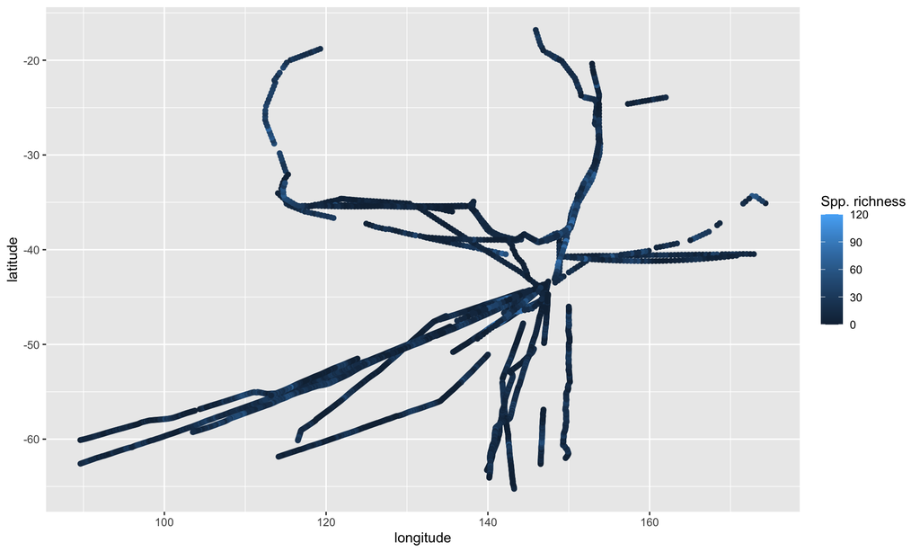

```r
ggplot(dat) +
  aes(x = longitude, y = latitude, color = richness_raw) +
  geom_point() +
  # change legend name
  labs(color = "Spp. richness")
```

Looks like species richness is slightly higher in the north than the south.

## 5.2 Check for other patterns

Visualize richness in a non-spatial way (latitude on x-axis, richness on y-axis):

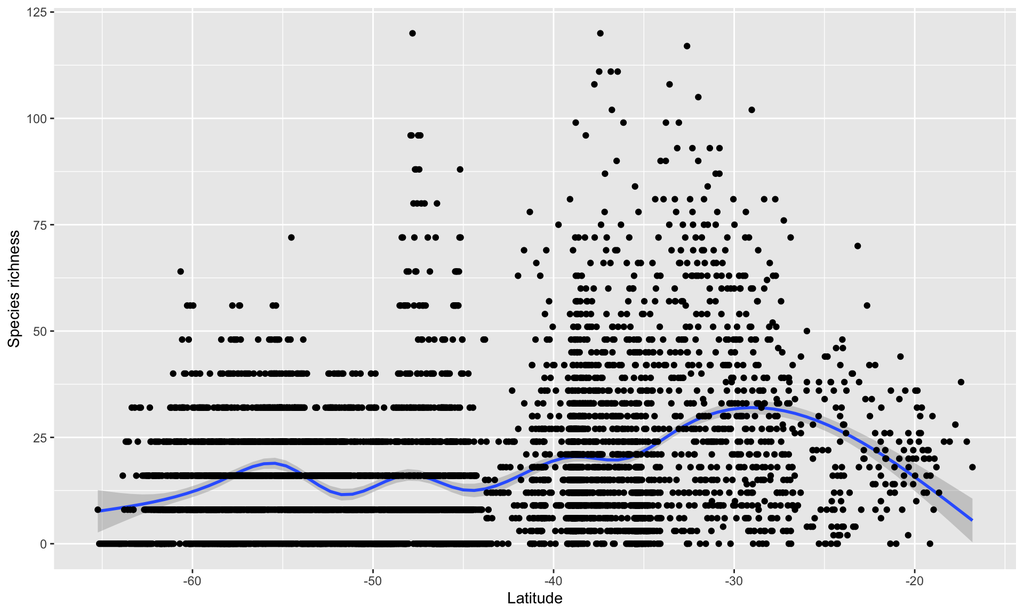

```r
ggplot(dat, aes(x = latitude, y = richness_raw)) +
  stat_smooth() +
  geom_point() +
  labs(x = "Latitude", y = "Species richness")
```

At latitude -40, there is an unnatural change in the data pattern. We don’t know what is causing this yet.

# 6 Getting started with maps

Let’s repeat the latitude vs. richness map, but with R’s specialist packages for GIS and mapping.

- We want to reference the data to real locations on the planet, and bend it around a mostly spherical ball (i.e. earth).

First, using the `sf` package, we will turn the point data into a spatially referenced data frame. Similar to a shapefile for feature collection in GIS.

```r
sdat <- st_as_sf(dat, coords = c("longitude", "latitude"), crs = 4326)
```

## 6.1 Coordinate Reference System

Coordinate reference systems are required for 2D mapping to compensate for the 3D nature of the earth.

In mapping, the reference point is referred to as “datum” and the lumpy earth model as “ellipsoid”. Together they make up the geographic coordinate reference system, which tells us where the copepod data coordinates are located on earth.

To accurately map our data, we need to decide how to ‘project’ 3 dimensions into 2. There are many ways this can be done depending on where we are in the world and what we’re most interested in preserving (e.g. angles vs. distances vs. area). Projections are defined by a projected coordinate reference system (PCS); R spatial packages use the *PROJ* software to do this.

- The R package `crsuggest` can be used to help find the most suitable project CRS for your data.

# 7 Feature collection (points)

|  | silk_id | segment_no | sample_time_utc | project | route | vessel | meanlong | region | richness_raw | geometry |
| --- | --- | --- | --- | --- | --- | --- | --- | --- | --- | --- |
| 1 | 1 | 1 | 26/06/2009 22:08 | AusCPR | BRSY | ANL Windarra | 153.2466 | East | 3 |  |
| 2 | 1 | 5 | 26/06/2009 23:12 | AusCPR | BRSY | ANL Windarra | 153.2466 | East | 21 |  |
| 3 | 1 | 9 | 27/06/2009 0:17 | AusCPR | BRSY | ANL Windarra | 153.2466 | East | 27 |  |
| 4 | 1 | 13 | 27/06/2009 1:22 | AusCPR | BRSY | ANL Windarra | 153.2466 | East | 54 |  |
| 5 | 1 | 17 | 27/06/2009 2:26 | AusCPR | BRSY | ANL Windarra | 153.2466 | East | 24 |  |
| 6 | 1 | 18 | 27/06/2009 2:43 | AusCPR | BRSY | ANL Windarra | 153.2466 | East | 18 |  |
| 7 | 1 | 26 | 27/06/2009 4:52 | AusCPR | BRSY | ANL Windarra | 153.2466 | East | 36 |  |
| 8 | 1 | 30 | 27/06/2009 5:57 | AusCPR | BRSY | ANL Windarra | 153.2466 | East | 9 |  |
| 9 | 1 | 33 | 27/06/2009 6:45 | AusCPR | BRSY | ANL Windarra | 153.2466 | East | 24 |  |
| 10 | 1 | 37 | 27/06/2009 7:50 | AusCPR | BRSY | ANL Windarra | 153.2466 | East | 36 |  |

[output cut: 5303 more lines]

Note the `geometry` column, which is where the coordinates are stored.

In summary, a simple feature (sf) is like a shapefile in that it holds data in rows and columns but is spatially aware.

# 8 Cartography

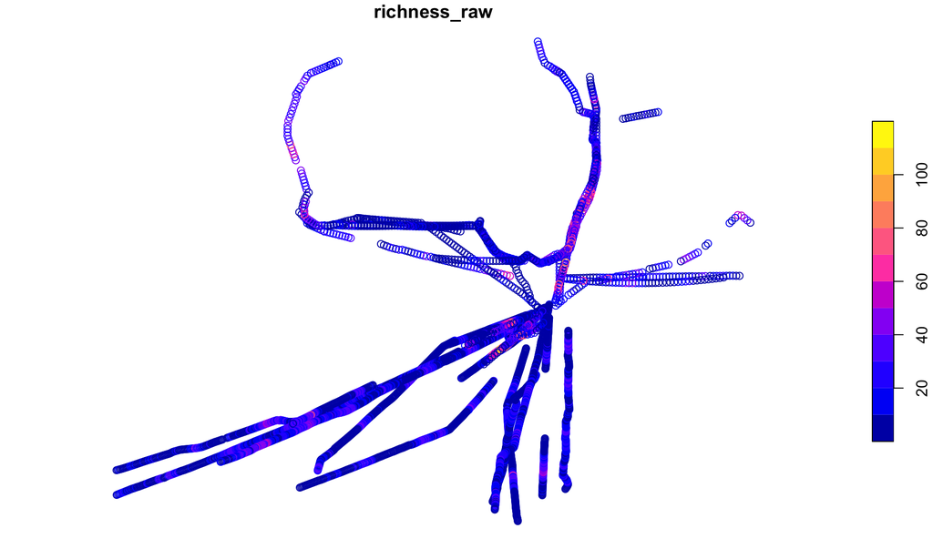

```r
plot(sdat["richness_raw"])
```

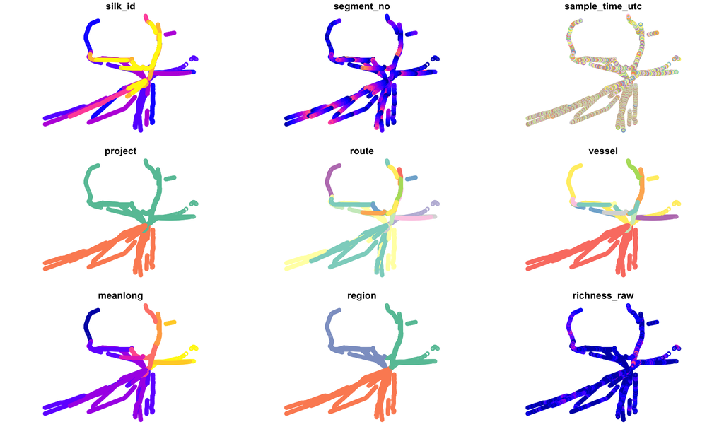

```r
plot(sdat)
```

# 9 Thematic maps

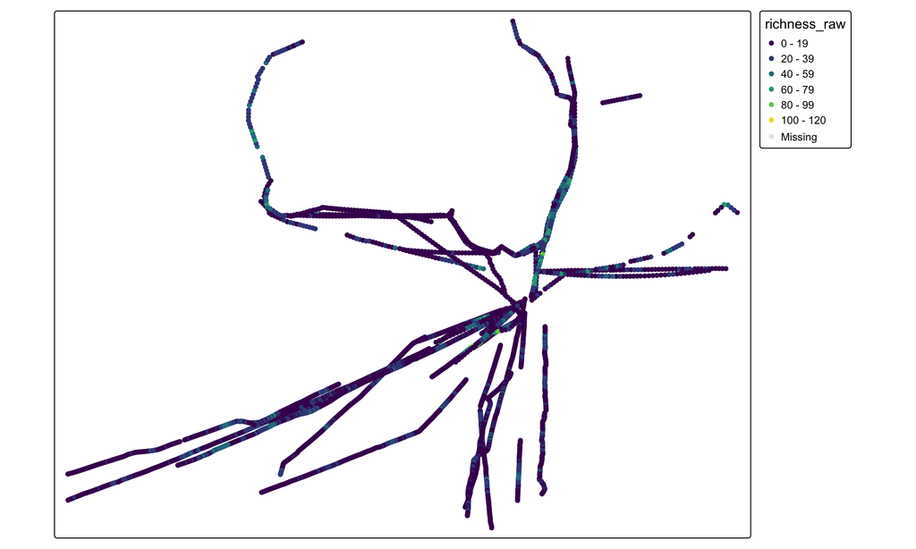

```r
# plotting using 'tmap'

tm_shape(sdat) +
  tm_dots(col = "richness_raw", palette = "viridis")
```

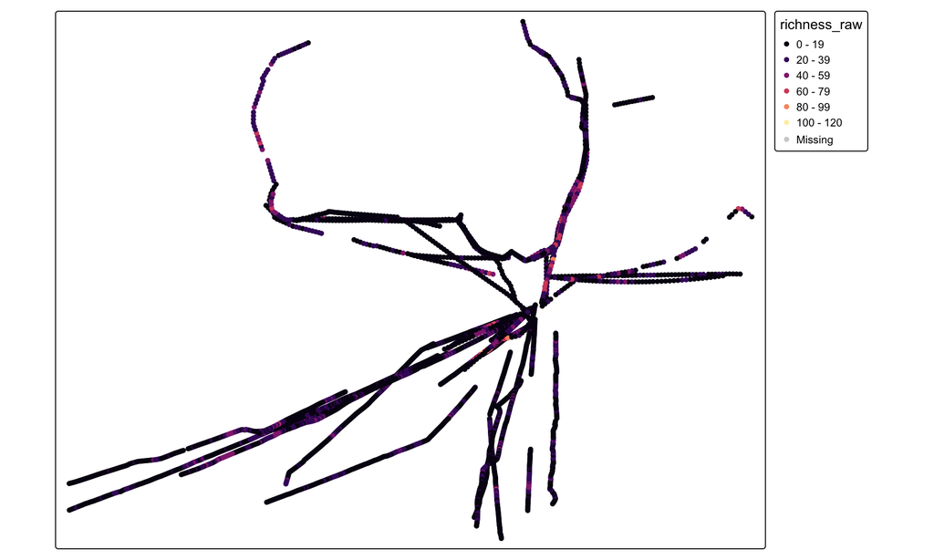

```r
tm_shape(sdat) +
  tm_dots(col = "richness_raw", palette = "magma")
```

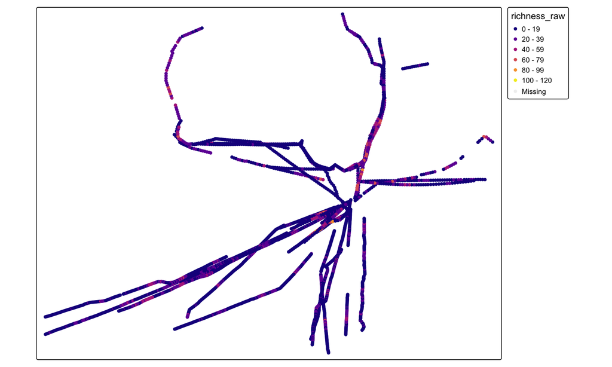

```r
tm_shape(sdat) +
  tm_dots(col = "richness_raw", palette = "plasma")
```

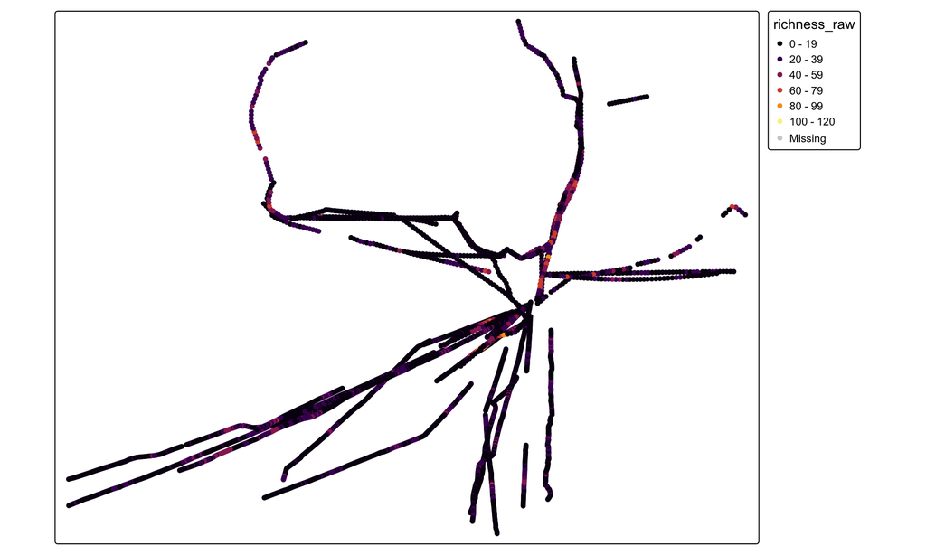

```r
tm_shape(sdat) +
  tm_dots(col = "richness_raw", palette = "inferno")
```

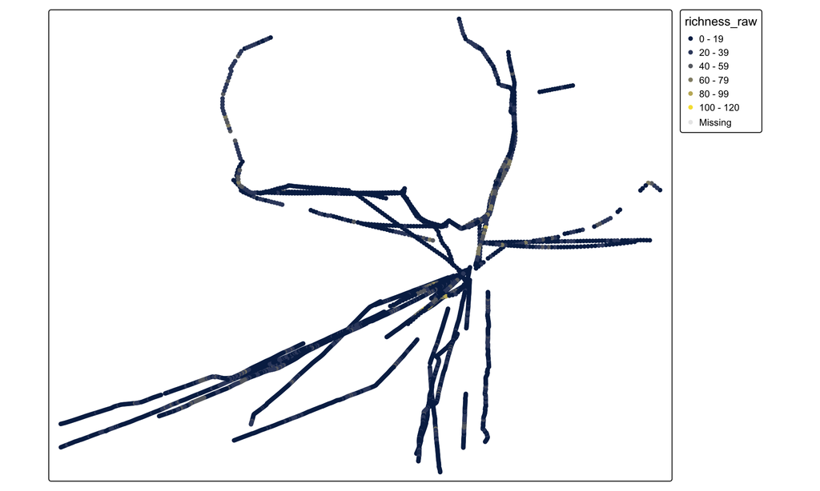

```r
tm_shape(sdat) +
  tm_dots(col = "richness_raw", palette = "cividis")
```

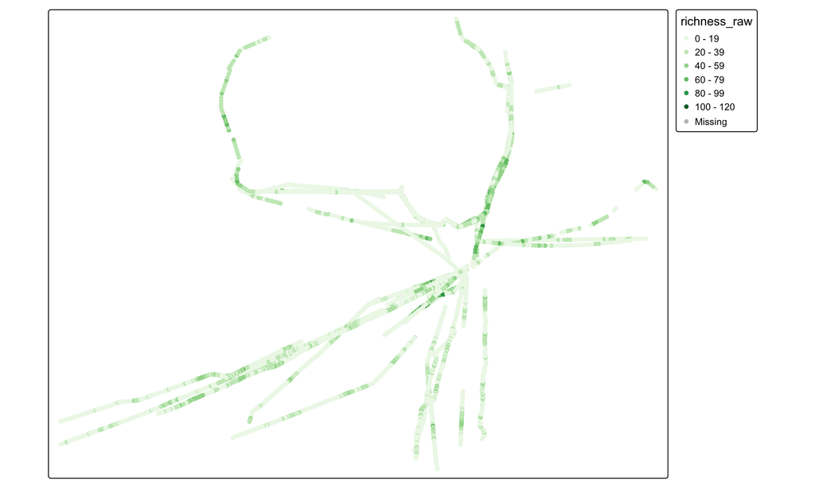

```r
tm_shape(sdat) +
  tm_dots(col = "richness_raw", palette = "Greens")
```

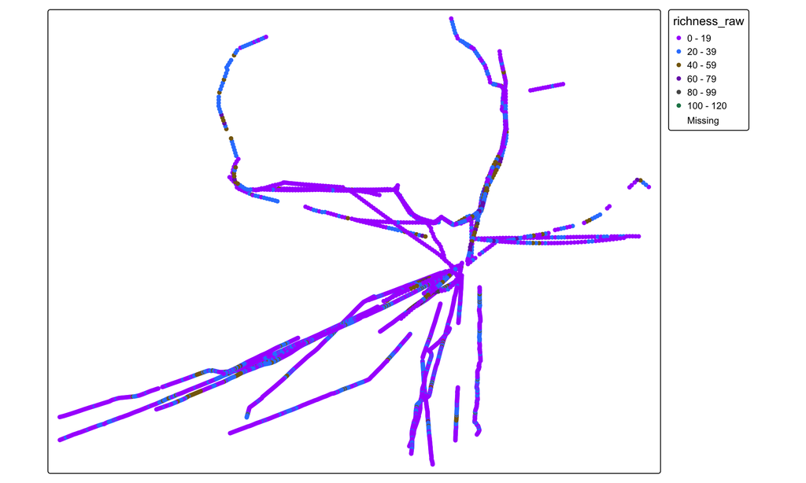

```r
tm_shape(sdat) +
  tm_dots(col = "richness_raw", palette = "Alphabet")
```

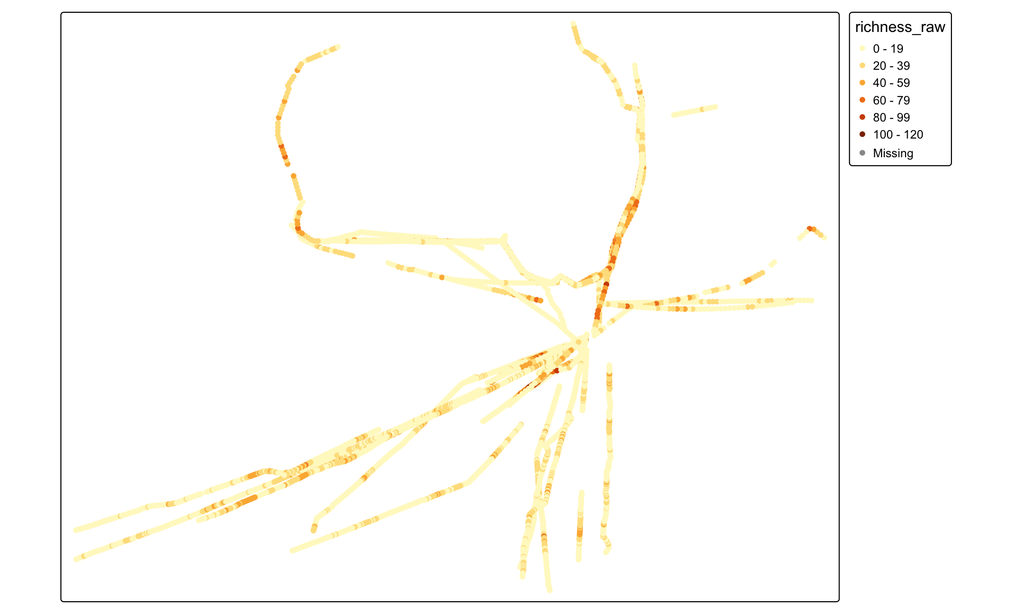

```r
tm1 <- tm_shape(sdat) +
  tm_dots(col = "richness_raw", palette = "tol.wh_or_br")
tm1
```

```r
# c4a_palettes()
```

```r
tmap_save(tm1, filename = here::here("output/richness-map.png"),
          width = 1800, height = 1600)
```

# 10 Mapping spatial polygons as layers

The `sf` package can also handle shapes (like polygons) for spatial data. Let’s practice by loading a map of Australia & a map of Australia’s continental shelf using `tmap`.

## 10.1 Loading shapefiles

Shapefiles can be read directly into R with the st_read command (like read_csv, but for spatial files):

```r
aus <- st_read(here("data/workshop4/data-for-course/spatial-data/Aussie/Aussie.shp"))
```

```r
aus
```

| adm | geometry |
| --- | --- |
| NSW |  |
| Vic |  |
| QLD |  |
| SA |  |
| WA |  |
| Tas |  |
| NT |  |
| ACT |  |

```r
shelf <- st_read(here("data/workshop4/data-for-course/spatial-data/aus_shelf/aus_shelf.shp"))
```

```r
shelf
```

| FID | geometry |
| --- | --- |
| 0 |  |

## 10.2 Mapping the polygons

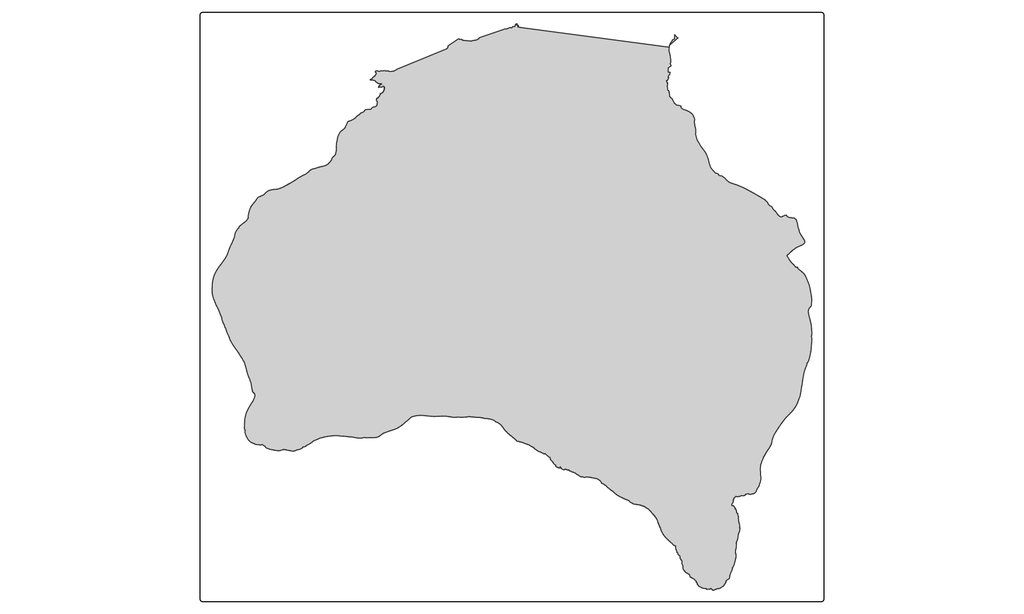

```r
tm_shape(shelf) +   # Australia's coastal shelf
  tm_polygons()
```

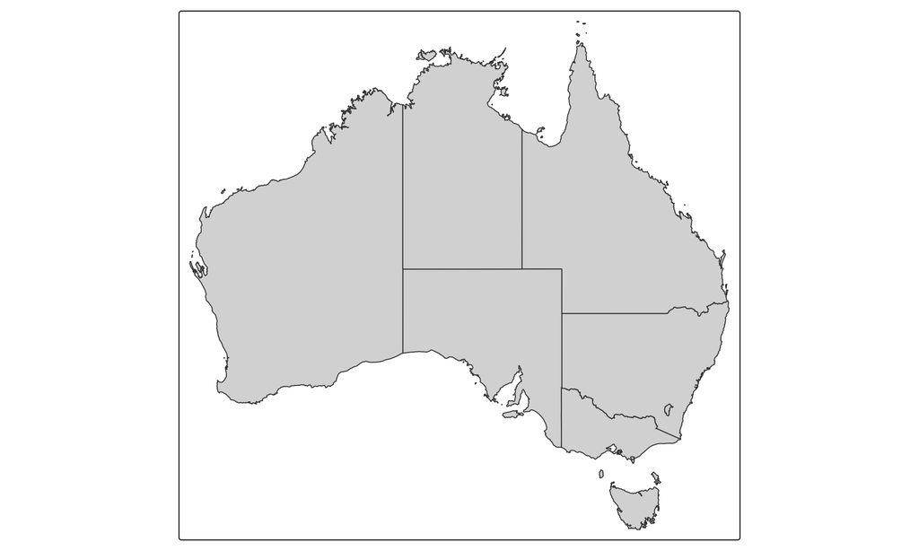

```r
tm_shape(aus) +   # Australia with state boundary lines
  tm_polygons()
```

```r
# Check CRS of layers:
st_crs(aus)
st_crs(shelf)
st_crs(sdat)
```

[output not shown]

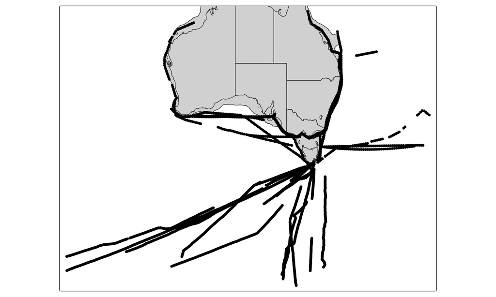

```r
tm_shape(shelf, bbox = sdat) +
  tm_polygons() +
  tm_shape(aus) +
  tm_polygons() +
  tm_shape(sdat) +
  tm_dots()
```

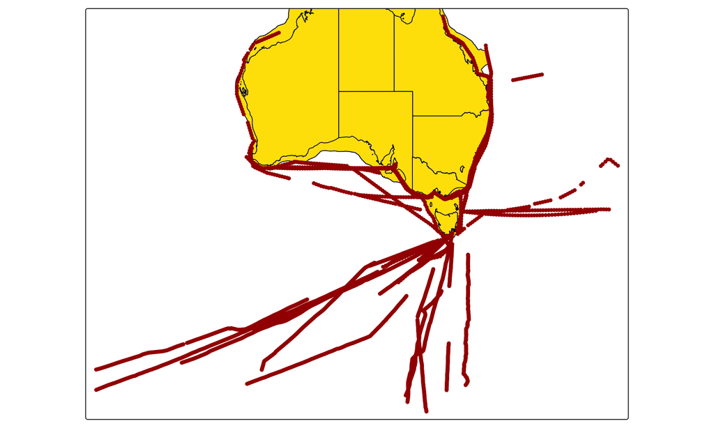

```r
tmap_style("beaver")

tm_shape(shelf, bbox = sdat) +
  tm_polygons() +
  tm_shape(aus) +
  tm_polygons() +
  tm_shape(sdat) +
  tm_dots()
```

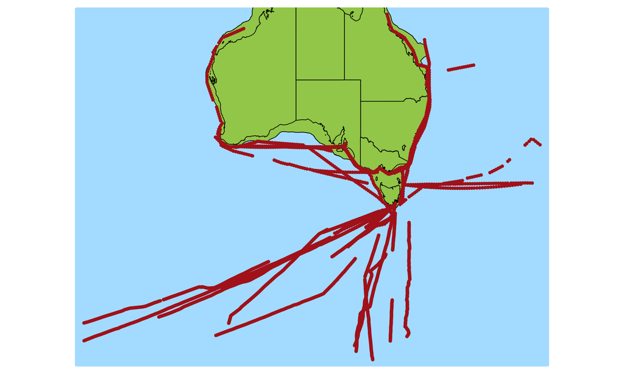

```r
tmap_style("natural")

tm_shape(shelf, bbox = sdat) +
  tm_polygons() +
  tm_shape(aus) +
  tm_polygons() +
  tm_shape(sdat) +
  tm_dots()
```